# Assignment3

Fengfan

13/10/2021

## 2. Tidy data and iteration

### 2.1 Missing data and iteration

Load library

```r
library(tidyverse)
```

The following function performs imputation by mean.

```r
impute_by_mean <- function(x) {
  mu <- mean(x, na.rm=1)
  impute_f <- function(z) {
    if (is.na(z)) {
      return (mu)
    } else {
      return (z)
    }
  }

  return (map_dbl(x, impute_f))
}
```

Using the function to imput the missing value with mean.

```r
v <- c(1,2,NA,4)
impute_by_mean(v)
```

```
## [1] 1.000000 2.000000 2.333333 4.000000
```

Create a function called *impute_by_median* which imputes missing values based on the median of the sample rather than mean.

```r
impute_by_median <- function(x) {
  med <- median(x, na.rm=1)
  impute_f <- function(z) {
    if (is.na(z)) {
      return (med)
    } else {
      return (z)
    }
  }
  return (map_dbl(x, impute_f))
}
```

Test function on the following sample vector:

```r
v <- c(1,2,NA,4)
impute_by_median(v)
```

```
## [1] 1 2 2 4
```

Generate a data frame with two variables x and y.

```r
x <- seq(0, 10, 0.1)
y <- x*5 + 1
df_xy <- data.frame(x, y)

df_xy %>% head(5)
```

```
##     x   y
## 1 0.0 1.0
## 2 0.1 1.5
## 3 0.2 2.0
## 4 0.3 2.5
## 5 0.4 3.0
```

The `map2()` funtion is similar to the `map()` function but iterates over two variables in parallel rather than one. Now add a new column named z which is x+y.

```r
df_xy %>% mutate(z=map2_dbl(x, y, ~ .x+.y)) %>% head(5)
```

```
##     x   y   z
## 1 0.0 1.0 1.0
## 2 0.1 1.5 1.6
## 3 0.2 2.0 2.2
## 4 0.3 2.5 2.8
## 5 0.4 3.0 3.4
```

```r
somtimes_missing <- function(index, value) {
  if (index %% 5 == 0){
    return (NA)
  } else {
    return (value)
  }
}

somtimes_missing(14, 25)
```

```
## [1] 25
```

```r
somtimes_missing(15, 25)
```

```
## [1] NA
```

```r
df_xy_missing <- df_xy %>% mutate(y=map2_dbl(row_number(x), y, somtimes_missing))
head(df_xy_missing)
```

```
##     x   y
## 1 0.0 1.0
## 2 0.1 1.5
## 3 0.2 2.0
## 4 0.3 2.5
## 5 0.4  NA
## 6 0.5 3.5
```

Imputing the missing value from *df_xy_missing* by the median value.

```r
df_xy_imputed <- df_xy_missing %>% mutate(y=impute_by_median(y))

head(df_xy_imputed)
```

```
##     x    y
## 1 0.0  1.0
## 2 0.1  1.5
## 3 0.2  2.0
## 4 0.3  2.5
## 5 0.4 26.0
## 6 0.5  3.5
```

```r
df_xy <- df_xy %>% mutate(source="original")

df_xy_missing <- df_xy_missing %>% mutate(source="corrupted")

df_xy_imputed <- df_xy_imputed %>% mutate(source="imputed")

df_combined <- rbind(df_xy, df_xy_missing, df_xy_imputed)
head(df_combined)
```

```
##     x   y   source
## 1 0.0 1.0 original
## 2 0.1 1.5 original
## 3 0.2 2.0 original
## 4 0.3 2.5 original
## 5 0.4 3.0 original
## 6 0.5 3.5 original
```

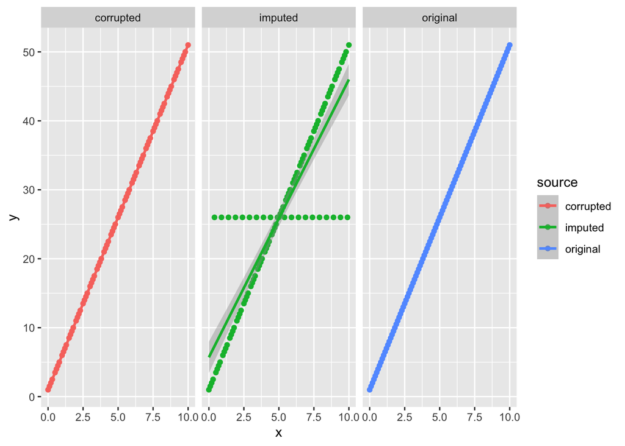

```r
ggplot(df_combined, aes(x=x,y=y,color=source))+geom_point()+facet_wrap(~source)+geom_smooth(method="lm")
```

Do the imputed values $y_{i}^{'}$ give reasonable estimates of the true values $y_{i}$?

[output not shown]

### 2.2 Tidying data with pivot functions

Read in data from a spreadsheet and apply some data wrangling tasks to tidy that data.

```r
# install.packages("readxl")
```

```r
library(readxl)

folder_path <- "/Users/frankhu/Documents/SCEM/firstRProject/resources/"
file_name <- "HockeyLeague.xlsx"
file_path <- paste(folder_path, file_name, sep="")
wins_data_frame <- read_excel(file_path, sheet="Wins")
```

```
## * `` -> ...1
```

Inspect the first 3 rows of the first five columns:

```r
wins_data_frame %>% select(1:5) %>% head(3)
```

```
## # A tibble: 3 × 5
##   ...1   `1990`   `1991`   `1992`   `1993`
##   <chr>  <chr>    <chr>    <chr>    <chr>
## 1 Ducks  30 of 50 11 of 50 30 of 50 12 of 50
## 2 Eagles 24 of 50 12 of 50 37 of 50 14 of 50
## 3 Hawks  20 of 50 22 of 50 33 of 50 11 of 50
```

A cell value of the form “a of b” means that a games were won out of a total of b for that season.

Is this tidy data?

[output not shown]

Now apply your data wrangling skills to transform the “wins_data_frame” data frame object into a data frame called “wins_tidy” which contains the same information but has just four columns entitled “Team”, “Year”, “Wins”, “Total”. The “Team” column should contain the team name, the “Year” column should contain the year, the “Wins” column should contain the number of wins for that season and the “Total” column the total number of games for that season. The first column should be of character type and the remaining columns should be of integer type. You can do this by combining the following functions: rename(), pivot_longer(), mutate() and separate().

```r
wins_tidy <- wins_data_frame %>% rename(Team="...1") %>% pivot_longer(cols=!Team, names_to = "Year", values_to = "Score") %>% separate(col = Score, into=c("Wins", "Total"), sep = "of", convert = TRUE)
wins_tidy
```

```
## # A tibble: 248 × 4
##    Team  Year   Wins Total
##    <chr> <chr> <dbl> <int>
##  1 Ducks 1990     30    50
##  2 Ducks 1991     11    50
##  3 Ducks 1992     30    50
##  4 Ducks 1993     12    50
##  5 Ducks 1994     24    50
##  6 Ducks 1995     13    50
##  7 Ducks 1996     25    50
##  8 Ducks 1997     24    50
##  9 Ducks 1998     27    50
## 10 Ducks 1999     23    50
## # … with 238 more rows
```

Check the shape of your data frame and the first five rows:

```r
wins_tidy %>% dim()
```

```
## [1] 248   4
```

```r
wins_tidy %>% head(5)
```

```
## # A tibble: 5 × 4
##   Team  Year   Wins Total
##   <chr> <chr> <dbl> <int>
## 1 Ducks 1990     30    50
## 2 Ducks 1991     11    50
## 3 Ducks 1992     30    50
## 4 Ducks 1993     12    50
## 5 Ducks 1994     24    50
```

```r
losses_data_frame <- read_excel(file_path, sheet="Losses")
```

```
## * `` -> ...1
```

```r
losses_tidy <- losses_data_frame %>% rename(Team="...1") %>% pivot_longer(cols=!Team, names_to = "Year", values_to = "Score") %>% separate(col = Score, into=c("Losses", "Total"), sep = "of", convert = TRUE)
losses_tidy
```

```
## # A tibble: 248 × 4
##    Team  Year  Losses Total
##    <chr> <chr>  <dbl> <int>
##  1 Ducks 1990      20    50
##  2 Ducks 1991      37    50
##  3 Ducks 1992       1    50
##  4 Ducks 1993      30    50
##  5 Ducks 1994       7    50
##  6 Ducks 1995       2    50
##  7 Ducks 1996      20    50
##  8 Ducks 1997       9    50
##  9 Ducks 1998      17    50
## 10 Ducks 1999      23    50
## # … with 238 more rows
```

You may notice that the number of wins plus the number of losses for a given team, in a given year does not add up to the total. This is because some of the games are neither wins nor losses but draws. That is, for a given year the number of draws is equal to the total number of games minus the sum of the wins and losses.

Now combine your two data frames, “wins_tidy” and “losses_tidy”, into a single data frame entitled “hockey_df” which has 248 rows and 9 columns: A “Team” column which gives the name of the team as a character, the “Year” column which gives the season year, the “Wins” column which gives the number of wins for that team in the given year, the “Losses” column which gives the number of losses for that team in the given year and the “Draws” column which gives the number of draws for that team in the given year, the “Wins_rt” which gives the wins as a proportion of the total number of games (ie. Wins/Total) and similarly the “Losses_rt” and the “Draws_rt” which gives the losses and draws as a proportion of the total, respectively. To do this you can make use of the mutate() function. You may also want to utilise the across() function for a slightly neater solution.

```r
hockey_df <- wins_tidy %>% inner_join(losses_tidy) %>% mutate(Draws=Total-Wins-Losses, Wins_rt=Wins/Total, Losses_rt=Losses/Total, Draws_rt=Draws/Total)
hockey_df %>% head(5)
```

```
## # A tibble: 5 × 9
##   Team  Year   Wins Total Losses Draws Wins_rt Losses_rt Draws_rt
##   <chr> <chr> <dbl> <int>  <dbl> <dbl>   <dbl>     <dbl>    <dbl>
## 1 Ducks 1990     30    50     20     0    0.6       0.4      0
## 2 Ducks 1991     11    50     37     2    0.22      0.74     0.04
## 3 Ducks 1992     30    50      1    19    0.6       0.02     0.38
## 4 Ducks 1993     12    50     30     8    0.24      0.6      0.16
## 5 Ducks 1994     24    50      7    19    0.48      0.14     0.38
```

To conclude this task generate a summary data frame which displays, for each team, the median win rate, the mean win rate, the median loss rate, the mean loss rate, the median draw rate and the mean draw rate. The number of rows in your summary should equal the number of teams. These should be sorted in descending order or median win rate. You may want to make use of the following functions: select(), group_by(), across(), arrange().

```r
unnecessary_cols <- c("Wins", "Losses", "Draws", "Team")
hockey_df %>% select(one_of(unnecessary_cols)) %>% group_by(Team) %>% summarise(across(everything(), list(mean=mean, median=median), .names="{.col}_{.fn}")) %>% arrange(desc(Wins_median)) # Ordering by decent median value of wins.
```

```
## # A tibble: 8 × 7
##   Team        Wins_mean Wins_median Losses_mean Losses_median Draws_mean Draws_median
##   <chr>           <dbl>       <dbl>       <dbl>         <dbl>      <dbl>        <dbl>
## 1 Eagles           24.5          25        15.7            14       16.3           18
## 2 Penguins         25.6          25        17.5            17       13.4            8
## 3 Ducks            20.2          23        18.8            17       17.5           15
## 4 Hawks            21.8          22        13.8            13       20.9           17
## 5 Ostriches        17.4          18        22.6            24       16.5           16
## 6 Owls             18.7          18        19              17       18.7           22
## 7 Storks           15.9          15        16.1            13       24.4           25
## 8 Kingfishers      13.8          14        20.6            19       22.1           22
```

### 2.3 Most correlated variables (*)

This data wrangling task is slightly more challenging. You may want to return to this task once you have completed the unstarred questions in sections 3 and 4 below.

The objective is to investigate, for each numerical variable within a data set, which other numerical variables have the largest correlation (in absolute value).

In lecture 6 we introduced the following function called “max_cor_var”. The function entitled “max_cor_var” takes as input a data frame “df” and a column name “col_name”. It then extracts the variable with name col_name and determines which other numerical variables within the data set have the highest correlation (in absolute value) with that variable. It then returns a data frame containing the name of the variable “var_name” and the corresponding correlation “cor”. Begin by making sure you understand the structure of the function.

```
select_if(): This verb is analogous to summarise_if() and mutate_if() in that it lets you use a predicate on the columns of a data frame. Only those columns for which the predicate returns TRUE will be selected.
```

```r
max_cor_var<-function(df,col_name){
# function to determine the variable with maximal correlation
v_col<-df%>%select(all_of(col_name)) # extract variable based on col_name
  df_num<-df%>%
    select_if(is.numeric)%>%
    select(-all_of(col_name))
  # select all numeric variables excluding col_name
correlations<-unlist(map(df_num, function(x){cor(x,v_col,use="complete.obs")}))
  # compute correlations with all other numeric variables
max_abs_cor_var<-names(which(abs(correlations)==max(abs(correlations)))) # extract the variable name
cor<-as.double(correlations[max_abs_cor_var])
# compute the correlation

  return(data.frame(var_name=max_abs_cor_var,cor=cor))
  # return dataframe
}
```

```r
library(palmerpenguins)
```

Next generate a new function called “top_correlates_by_var” which takes input a data frame “df” and outputs a data frame with a single row. The column names of this output data frame should coincide with the names of the numerical columns within the input dataframe “df”. For each column name, the value should be equal to variable name corresponding to the numerical variable which has the highest level of correlation (in absolute value) to the variable with that column name, but is not equal to it.

```r
top_correlates_by_var <- function(df) {
  numeric_col_names <- df %>% select_if(is.numeric) %>% colnames
  dfs <- numeric_col_names %>% map(~max_cor_var(df, .x))
  # Get the top correlate values.
  top_correlates_values <- dfs %>% map(~.x$var_name)
  res <- list()
  for (i in 1:length(numeric_col_names)) {
    res[numeric_col_names[i]] = top_correlates_values[i]
  }
  return (tibble(data.frame(res)))
}
```

You can test your function as follows. By using the Palmer penguins data set you should obtain the following output.

```r
penguins %>% top_correlates_by_var()
```

```
## # A tibble: 1 × 5
##   bill_length_mm    bill_depth_mm     flipper_length_mm body_mass_g   year
##   <chr>             <chr>             <chr>             <chr>         <chr>
## 1 flipper_length_mm flipper_length_mm body_mass_g       flipper_leng… flipper_l…
```

Next use a combination of the functions group_by(), nest(), mutate(), select(), unnest() together with your new function top_correlates_by_var() to determine those variables with highest correlation, broken down by species of penguin. Your results should be as follows.

```r
penguins %>%
  group_by(species) %>%
  nest() %>%
  mutate(max_cor=map(data, ~top_correlates_by_var(.x))) %>%
  select(-data) %>%
  unnest()
```

```
## # A tibble: 3 × 6
## # Groups:   species [3]
##   species   bill_length_mm bill_depth_mm  flipper_length_… body_mass_g  year
##   <fct>     <chr>          <chr>          <chr>            <chr>        <chr>
## 1 Adelie    body_mass_g    body_mass_g    body_mass_g      bill_depth_… flipper…
## 2 Gentoo    body_mass_g    body_mass_g    bill_depth_mm    bill_depth_… bill_de…
## 3 Chinstrap bill_depth_mm  bill_length_mm body_mass_g      flipper_len… flipper…
```

## 3. Elementary set theory

Remember that a set is just a collection of objects. All that matters for the identity of a set is the objects it contains. In particular, the elements within the set are unordered, so for example the set {1, 2, 3} is exactly the same as the set {3, 2, 1}. In addition, since sets are just collections of objects, each object can only be either included or excluded and multiplicities do not change the nature of the set. In particular, the set {1,2,2,2,3,3} is exactly the same as the set A = {1,2,3}. In general there is no concept of “position” within a set, unlike a vector or matrix.

### 3.1 Rolling a dice

Let’s suppose we role a dice. The set of possible outcomes is Ω := {1, 2, 3, 4, 5, 6} corresponding to the different sides of the dice which could land face up.

Let’s introduce events A, B defined by A := {1,2,3}, B := {2,4,6}, C := {4,5,6}.

**Unions**

What is $A\cup B$?

```
{1,2,3,4,6}
```

What is $A\cup C$?

```
{1,2,3,4,5,6}
```

**Intersection**

What is $A\cap B$?

```
{2}
```

What is $A\cap C$?  
$\emptyset$

**Complements**  
What is A? What’s A?

```
# A\B -> Complement of B in A
A\B = {1,2,3} - {2} = {1,3}

# A\C -> Complement of C in A
A\C = {1,2,3} - {} = {1,2,3}
```

**Disjointness**  
Are A and B disjoint?  
No, cause $A\cap B \neq \emptyset$

Are A and C disjoint?  
Yes, cause $A\cap C = \emptyset$

**Partitions**  
Write down a partition of $\Omega:={1,2,3,4,5,6}$ consisting of two sets.

```
{1,2,3}, {4,5,6}
```

Write down another partition of $\Omega$ containing of three sets.

```
{1,2}, {3,4}, {5,6}
```

### 3.2 Complements, subsets and De Morgan’s laws

Let Ω be a sample space. Recall that for an event A⊆Ω the complement $A^c$ ≡Ω:={ω∈Ω : ω∈/A}. Take a pair of events A ⊆ Ω and B ⊆ Ω.

**Complements**  
Can you give an expression for $(A^c)^c$ without using the notion of a complement?

```
The complement of the complement is just the set itself, so it should be A.
```

What’s is $\Omega^c$?

```
I really don't know, I think the emptyset is a subset of the sample space. So the complement of Omega may be nothing (not emptyset).
```

**Intersections**  
Shows that $(A\cap B)^c=A^c\cup B^c$

Let’s suppose we have a sequence of events $A_1, A_2, ..., A_k \subseteq \Omega$. Can you write out an expression for $(\bigcap_{k=1}^{K}A_k)^c$ in terms of unions and complements?

Answer: $(\bigcup_{k=1}^{K}A_k^c)$

**Union**  
Shows that $(A\cup B)^c=A^c\cap B^c$

Let’s suppose we have a sequence of events $A_1, A_2, ..., A_k \subseteq \Omega$. Can you write out an expression for $(\bigcup_{k=1}^{K}A_k)^c$ in terms of intersections and complements?

Answer: $(\bigcap_{k=1}^{K}A_k^c)$

**De Morgans’ laws:** $(A\cup B)^c=A^c\cap B^c, (A\cap B)^c=A^c\cup B^c$

### 3.3 Cardinality and the set of all subsets

Suppose that $\Omega = \{\omega_1,\omega_2, ..., \omega_k\}$ contains K elements for some natural number $K\in \mathbb N$. Hence K has cardinality K.

Let $\varepsilon:=\{A \subseteq \Omega\}$ be the set of all subsets. Give a formula for the cardinality of $\varepsilon$ in terms of K.  
Answer:  
- One element: $C_{k}^1$

- Two elements: $C_{k}^2$
- n elements: $C_{k}^n$
- The sum of them: $2^k$  
  For each subset, it can in or not in A.

### 3.4 Disjointness and partitions

Suppose we have evnets $A_1, A_2, A_3, A_4$ all subsets of $\Omega$.  
Define events $S_1, S_2, S_3, S_4$ all subsets of $\Omega$ by $S_1:=A_1,S_2:=A_2/A_1,S_3:=A_3/(A_1\cup A_2), S_4:=A_4/(A_1\cup A_2 \cup A_3)$  
Show that $S_1, S_2, S_3, S_4$ from a partition of $A_1\cup A_2\cup A_3\cup A_4$.

**Answer**: Cause $A_1, A_2, A_3, A_4$ consist of the whole sample space $Omega$, so $S_1, S_2, S_3, S_4$ are disjointed and consist of the whole sample space. Thus they are partitions of $\Omega$.

### 3.5 Uncountable infinites (**)

Show that the set of numbers Ω := [0, 1] is uncountably infinite.

**Answer:** We know that $\mathbb N$ are countable infinite.

[Reference](https://en.wikipedia.org/wiki/Cantor%27s_diagonal_argument)

## 4. Introduction to probability

### 4.1 Probability of a complement

Prove that if Ω is a sample space, S ⊆ Ω is an event and $S^c$ ≡ Ω S is its complement we have
$$\mathbb P(S^c) = 1 - \mathbb P(S)$$
**Answer:** According to the probability principle $P(\Omega)=P(S\cup S^c)=1$, thus $P(S^c)=1-P(S)$

### 4.2 The union bound

Having $\mathbb P(\bigcup_{i=1}^{\infty} A_{i})= \Sigma_{i=0}^{\infty} \mathbb P(A_i)$ and $\mathbb P(\bigcup_{i=1}^{\infty}S_i)\le \Sigma_{i=1}^{\infty} \mathbb P(S_i)$, where $S_i$ are not necessarily disjointed.

Given an example sequences of $A_1, A_2, A_3 ...$ in which $\mathbb P(\bigcup_{i=1}^{\infty}A_i) \neq \Sigma_{i=1}^{\infty} \mathbb P(A_i)$

**Answer:** Rolling dice, for $A_1=\{1,2,3,4\}$, $A_2=\{5,6\}$, $A_3=\{3,5,6\}$, we know that $P(A_1\cup A_2 \cup A_3)=1$. However, $P(A_1)+P(A_2)+P(A_3)= 2/3 + 1/3 + 1/2 = 3/2$.

### 4.3 Verifying the rules of probability

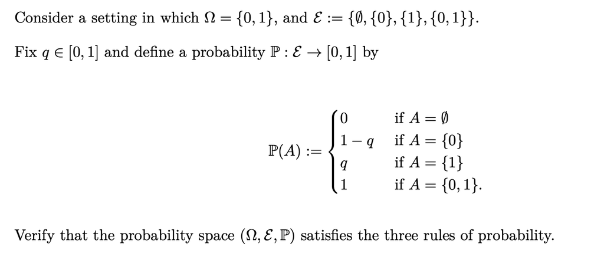

**Answer:**

1. For every $A\in \varepsilon$ , $\mathbb P(A) \ge 0$.
2. $\mathbb P(\Omega) = 1$.
3. For every countably pair-wise disjoint events $A_1, A_2, ...$, we have $\mathbb P(\bigcup_{i=1}^{\infty} A_{i})= \Sigma_{i=0}^{\infty} \mathbb P(A_i)$, i.e. $P(A+B) = P(A)+ P(B)$

### 4.4 Rotation invariant measures on [0,1] (***)